# Amazon Fine Food Reviews- Support Vector Machines

```python
#importing necessary packages
import sqlite3
import pandas as pd
import numpy as np
from sklearn.preprocessing import StandardScaler
import matplotlib.pyplot as plt
import seaborn as sns
import nltk
from sklearn.feature_extraction.text import CountVectorizer,TfidfVectorizer
import pickle
import sklearn.cross_validation
from sklearn.model_selection import train_test_split
from collections import Counter
from sklearn.metrics import accuracy_score
from sklearn import cross_validation
from sklearn.metrics import precision_score,recall_score,f1_score,confusion_matrix,roc_auc_score,roc_curve
```

## Reading already Cleaned, Preprocessed data from database

After removing stopwords, punctuations, meaningless characters, HTML tags from Text and done stemming. Using it directly as it was alredy done in prevoius assignment

```python
#Reading
conn= sqlite3.connect('cleanedTextData.sqlite')
data= pd.read_sql_query('''
SELECT * FROM Reviews
''',conn)
data=data.drop('index',axis=1)
data.shape
```

```
(364171, 11)
```

```python
data.columns
```

```
Index(['Id', 'ProductId', 'UserId', 'ProfileName', 'HelpfulnessNumerator',
       'HelpfulnessDenominator', 'Score', 'Time', 'Summary', 'Text',
       'CleanedText'],
      dtype='object')
```

```python
data['CleanedText'].head(3)
```

```
0    witti littl book make son laugh loud recit car...
1    rememb see show air televis year ago child sis...
2    beetlejuic well written movi everyth act speci...
Name: CleanedText, dtype: object
```

# Linear Kernel (100k datapoints)

## Sorting on the basis of 'Time' and taking top 100k pts

This data has time attribute so it will be reasonable to do time based splitting instead of random splitting.

So, before splitting we have to sort our data according to time and here we are taking 100k points from our dataset(population)

```python
data["Time"] = pd.to_datetime(data["Time"], unit = "ms")
data = data.sort_values(by = "Time")
```

```python
#latest 100k points according to time
data= data[:100000]
len(data)
```

```
100000
```

## Splitting data into train60% cv20 test20%

Splitting our data into train and test data.

- train data will train our ML model
- cross validataion data will be for determining our hyperparameter
- test data will tell how Generalized our model is
- dataframes after splitting:- traindata, cvdata, testdata

```python
traindata, testdata= train_test_split(data, test_size= 0.2, shuffle= False,stratify= None)
traindata, cvdata= train_test_split(traindata, test_size= 0.25, shuffle= False,stratify= None)
print(len(traindata),len(cvdata),len(testdata))
```

```
60000 20000 20000
```

```python
Xtrain,Xcv,Xtest= traindata['CleanedText'],cvdata['CleanedText'],testdata['CleanedText']
Ytrain,Ycv,Ytest= traindata['Score'],cvdata['Score'],testdata['Score']
```

```python
# converting positive to 1 and negative to -1
Ytrain=Ytrain.map(lambda x:1 if x=='Positive' else -1)
Ycv=Ycv.map(lambda x:1 if x=='Positive' else -1)
Ytest=Ytest.map(lambda x:1 if x=='Positive' else -1)
```

Taking Text and score(class) as sequences

- traindata -> Xtrain, Ytrain
- cvdata -> Xcv, Ycv
- testdata -> Xtest, Ytest

```python
from sklearn.svm import SVC
from sklearn.linear_model import SGDClassifier
from sklearn.calibration import CalibratedClassifierCV,calibration_curve
from sklearn.model_selection import GridSearchCV
from sklearn.metrics import log_loss
import warnings
warnings.simplefilter(action='ignore', category=(FutureWarning,DeprecationWarning))
```

```python
def LinearSVCsearchCalib(Xtr,Xcv):
    '''
    Returns optimum alpha and penalty.
    We take use of CalibratedClassifierCV to find log-probabilities and further find log
    errors. Those parameters with least log_error will be our best parameters.
    We use cv data here
    It first compares C's with l2 reg then C's with l1 reg and result will be shown in two sets
    best out on two will be best hyperparameter
    '''
    alpha= [0.0001,0.001,0.01,0.1,1,10,100,1000,10000]
    log_errors= []
    for i in alpha:
        sgdC= SGDClassifier(loss='hinge',penalty='l2',alpha=i)
        calibSGD= CalibratedClassifierCV(sgdC,cv=5,method='isotonic')
        calibSGD.fit(Xtr,Ytrain)
        ypreds = calibSGD.predict_proba(Xcv)
        log_errors.append(log_loss(Ycv, ypreds, eps=1e-15, normalize=True))
    #getting score out of log error
    scores = 1 - np.array(log_errors)
    #plotting score vs parameters
    parameters= alpha
    print('Using L2 regularization:')
    plt.plot(parameters,scores)
    plt.xlabel('Hyperparameter alpha')
    plt.ylabel('log_loss')
    plt.title('log_loss vs alpha')
    plt.show()
    #showing best outcomes
    print('best log-loss - ',max(scores))
    print('best parameters using l2 is- ',alpha[log_errors.index(min(log_errors))])

    log_errors= []
    for i in alpha:
        sgdC= SGDClassifier(loss='hinge',penalty='l1',alpha=i)
        calibSGD= CalibratedClassifierCV(sgdC,cv=5,method='isotonic')
        calibSGD.fit(Xtr,Ytrain)
        ypreds = calibSGD.predict_proba(Xcv)
        log_errors.append(log_loss(Ycv, ypreds, eps=1e-15, normalize=True))
    #getting score out of log error
    scores = 1 - np.array(log_errors)
    #plotting score vs parameters
    parameters= alpha
    print('Using L1 regularization:')
    plt.plot(parameters,scores)
    plt.xlabel('Hyperparameter alpha')
    plt.ylabel('log_loss')
    plt.title('log_loss vs alpha')
    plt.show()
    #sowing best outcomes
    print('best log-loss - ',max(scores))
    print('best parameters using l1 is- ',alpha[log_errors.index(min(log_errors))])
```

```python
def performance(y_train_pred,y_pred,clf):
    '''
    This will predict some of model's performance metrics
    '''
    print("Accuracy on test set: %0.3f%%"%(accuracy_score(Ytest, y_pred)*100))
    print("Precision on test set: %0.3f"%(precision_score(Ytest, y_pred)*100))
    print("Recall on test set: %0.3f"%(recall_score(Ytest, y_pred)*100))
    print("F1-Score on test set: %0.3f"%(f1_score(Ytest, y_pred)*100))
    fpr_train,tpr_train,ts_train=roc_curve(Ytrain,y_train_pred)
    fpr,tpr,ts=roc_curve(Ytest,y_pred)
    plt.plot(fpr,tpr,label='TEST')
    plt.plot(fpr_train,tpr_train,label='TRAIN')
    plt.xlabel('False positive rate')
    plt.ylabel('True positive rate')
    plt.title('ROC curve')
    plt.legend()
    plt.show()
    print("Confusion Matrix of test set:\n [ [TN  FP]\n [FN TP] ]\n")
    df_cm = pd.DataFrame(confusion_matrix(Ytest, y_pred), range(2),range(2))
    sns.set(font_scale=1.4)#for label size
    sns.heatmap(df_cm, annot=True,annot_kws={"size": 16}, fmt='g')
```

# BOW Vectorization

Bow vectorization is basic technique to convert a text into numerical vector.

- We will build a model on train text using fit-transform
- Then transform (test) text on model build by train text
- Transformed data will be in the form of sparse matrix

```python
# vectorizing X and transforming
bowModel=CountVectorizer()
XtrainBOWV=bowModel.fit_transform(Xtrain.values)
```

```python
XcvBOWV= bowModel.transform(Xcv)
XtestBOWV= bowModel.transform(Xtest)
XtestBOWV.shape
```

```
(20000, 36270)
```

```python
#Standardizing vectors
std = StandardScaler(with_mean=False).fit(XtrainBOWV)
XtrainBOWV = std.transform(XtrainBOWV)
XcvBOWV = std.transform(XcvBOWV)
XtestBOWV = std.transform(XtestBOWV)
```

Below function will be called for getting best hyperparameters. There are two result sets:-

- One with C and l2 regularization
- other with C and l1 regulatization
- best out of both will be chosen

```
Using L2 regularization:
```

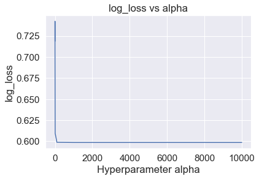

```
best log-loss -  0.7423950273107458
best parameters using l2 is-  0.1
Using L1 regularization:
```

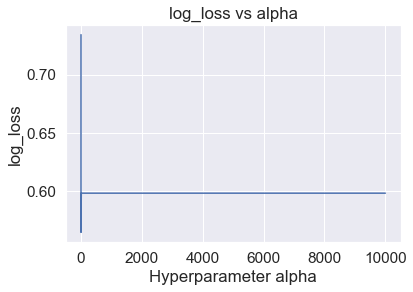

```
best log-loss -  0.734399158683549
best parameters using l1 is-  0.0001
```

```python
LinearSVCsearchCalib(XtrainBOWV,XcvBOWV)
```

It looks like l2 with alpha = 0.1 is the best parameter according to score

```python
#trianing finally
sgdBOW= SGDClassifier(loss='hinge', alpha=0.1, penalty='l2')
sgdBOW.fit(XtrainBOWV,Ytrain)
train_pred= sgdBOW.predict(XtrainBOWV)
pred= sgdBOW.predict(XtestBOWV)
```

```
Accuracy on test set: 90.610%
Precision on test set: 92.337
Recall on test set: 97.229
F1-Score on test set: 94.720
```

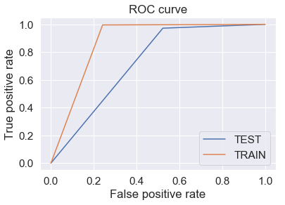

```
Confusion Matrix of test set:
 [ [TN  FP]
 [FN TP] ]
```

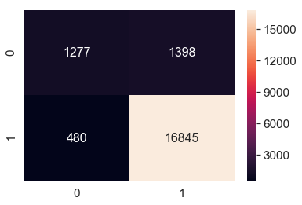

```python
performance(train_pred,pred,sgdBOW)
```

## Feature importance

```python
def show_most_informative_features(vectorizer, clf, n=15):
    feature_names = vectorizer.get_feature_names()
    coefs_with_fns = sorted(zip(clf.coef_[0], feature_names))
    top = zip(coefs_with_fns[:n], coefs_with_fns[:-(n + 1):-1])
    print("\t\t\tNegative\t\t\t\t\t\tPositive")
    print("________________________________________________________________________________________________")
    for (coef_1, fn_1), (coef_2, fn_2) in top:
        print("\t%.4f\t%-15s\t\t\t\t%.4f\t%-15s" % (coef_1, fn_1, coef_2, fn_2))

#Code Reference:https://stackoverflow.com/questions/11116697/how-to-get-most-informative-features-
#for-scikit-learn-classifiers
```

```python
show_most_informative_features(bowModel,sgdBOW)
```

```
			Negative						Positive
________________________________________________________________________________________________
	-0.1174	disappoint     				0.2018	great
	-0.0859	worst          				0.1836	love
	-0.0699	terribl        				0.1497	good
	-0.0664	unfortun       				0.1459	best
	-0.0644	return         				0.1040	delici
	-0.0636	aw             				0.0990	excel
	-0.0626	horribl        				0.0866	nice
	-0.0603	wast           				0.0866	favorit
	-0.0556	thought        				0.0794	tasti
	-0.0554	mayb           				0.0793	perfect
	-0.0542	bland          				0.0774	wonder
	-0.0540	sorri          				0.0675	find
	-0.0523	unpleas        				0.0665	use
	-0.0510	threw          				0.0599	easi
	-0.0481	stale          				0.0586	enjoy
```

# TFIDF vectorization

- We will build a model on train text using fit-transform
- Then transform (test) text on model build by train text
- Transformed data will be in the form of sparse matrix
- Then Standardize our data

```python
# generating vetor out of text using tfidf
tfidfModel=TfidfVectorizer()
XtrainTFIDFV= tfidfModel.fit_transform(Xtrain)
XcvTFIDFV= tfidfModel.transform(Xcv)
XtestTFIDFV= tfidfModel.transform(Xtest)
```

```python
std= StandardScaler(with_mean=False)
XtrainTFIDFV = std.fit_transform(XtrainTFIDFV)
XcvTFIDFV = std.transform(XcvTFIDFV)
XtestTFIDFV = std.transform(XtestTFIDFV)
```

```
Using L2 regularization:
```

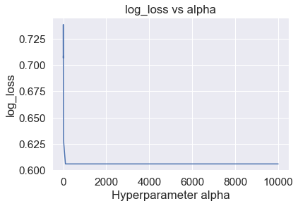

```
best log-loss -  0.7386173441056143
best parameters using l2 is-  0.1
Using L1 regularization:
```

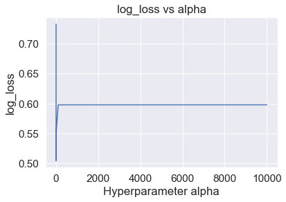

```
best log-loss -  0.732288124951558
best parameters using l1 is-  0.0001
```

```python
LinearSVCsearchCalib(XtrainTFIDFV,XcvTFIDFV)
```

```python
sgdTFIDF= SGDClassifier(loss='hinge', alpha=0.0001, penalty='l2')
sgdTFIDF.fit(XtrainTFIDFV,Ytrain)
train_pred= sgdTFIDF.predict(XtrainTFIDFV)
pred= sgdTFIDF.predict(XtestTFIDFV)
```

```
Accuracy on test set: 86.925%
Precision on test set: 92.613
Recall on test set: 92.266
F1-Score on test set: 92.439
```

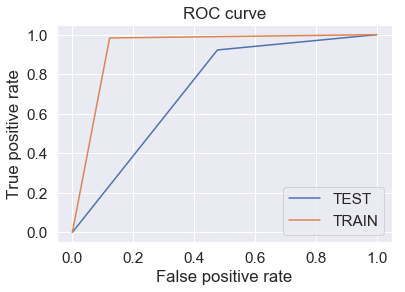

```
Confusion Matrix of test set:
 [ [TN  FP]
 [FN TP] ]
```

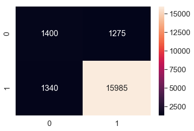

```python
performance(train_pred,pred,sgdTFIDF)
```

## Feature importance

```python
def show_most_informative_features(vectorizer, clf, n=15):
    feature_names = vectorizer.get_feature_names()
    coefs_with_fns = sorted(zip(clf.coef_[0], feature_names))
    top = zip(coefs_with_fns[:n], coefs_with_fns[:-(n + 1):-1])
    print("\t\t\tNegative\t\t\t\t\t\tPositive")
    print("________________________________________________________________________________________________")
    for (coef_1, fn_1), (coef_2, fn_2) in top:
        print("\t%.4f\t%-15s\t\t\t\t%.4f\t%-15s" % (coef_1, fn_1, coef_2, fn_2))

#Code Reference:https://stackoverflow.com/questions/11116697/how-to-get-most-informative-features-
#for-scikit-learn-classifiers
```

```python
show_most_informative_features(tfidfModel, sgdTFIDF, n=15)
```

```
			Negative						Positive
________________________________________________________________________________________________
	-24.4379	worst          				49.6235	great
	-19.8545	disappoint     				40.1818	love
	-13.6392	unpleas        				36.1969	best
	-12.8970	aw             				29.3371	delici
	-11.6628	thought        				27.7191	perfect
	-11.4945	bland          				25.1403	good
	-11.4907	peapod         				23.9224	favorit
	-11.3042	cartooni       				23.7174	excel
	-11.2877	tribun         				23.4098	nice
	-11.2876	unfortun       				19.7236	find
	-11.1819	welllll        				19.2820	wonder
	-11.1614	threw          				18.6928	amaz
	-10.9367	delud          				17.4770	addict
	-10.8164	squirmi        				17.3669	awesom
	-10.7524	terribl        				16.6705	keep
```

# Avg W2V vectorization

```python
import gensim
# training our gensim model on our train text
import re
import string
def cleanhtml(sentance): #substitute expression contained in <> with ' '
    cleaned= re.sub(re.compile('<.*?>'),' ',sentance)
    return cleaned
#function for removing punctuations chars
def cleanpunc(sentance):
    cleaned= re.sub(r'[?|!|\'|"|#]',r'',sentance)
    cleaned= re.sub(r'[.|,|)|(|\|/]',r'',sentance)
    return cleaned
i=0
lists=[]

for sent in Xtrain.values:
    filtered_sentence=[]
    sent=cleanhtml(sent)
    for w in sent.split():
        for cleaned_words in cleanpunc(w).split():
            if(cleaned_words.isalpha()):
                filtered_sentence.append(cleaned_words.lower())
            else:
                continue
    lists.append(filtered_sentence)


w2v_model= gensim.models.Word2Vec(lists,min_count=5,size=50,workers=4)
print(len(list(w2v_model.wv.vocab)))
```

```
9613
```

```python
w2v_words = list(w2v_model.wv.vocab)
```

```python
# converting list of sentance into list of list of words
# then to vector using avg w2v
# function to convert list of list of words to vect using avg w2v
def w2vVect(X):
    '''
    This function takes list of sentance as input (X) and convert it into
    list of list of words and then feed it into our gensim model to get vector
    and then take its average, finally returns sent_vectors(vector of sentance)
    *************GENSIM MODEL WAS TRAINED ON TRAINDATA***************
    '''

    lists=[]
    for sent in X.values:
        filtered_sentence=[]
        sent=cleanhtml(sent)
        for w in sent.split():
            for cleaned_words in cleanpunc(w).split():
                if(cleaned_words.isalpha()):
                    filtered_sentence.append(cleaned_words.lower())
                else:
                    continue
        lists.append(filtered_sentence)

    sent_vectors = [];
    for sent in lists:
        sent_vec = np.zeros(50)
        cnt_words =0;
        for word in sent:
            if word in w2v_words:
                vec = w2v_model.wv[word]
                sent_vec += vec
                cnt_words += 1
        if cnt_words != 0:
            sent_vec /= cnt_words
        sent_vectors.append(sent_vec)
    return sent_vectors
```

```python
# Vectorizing our data
XtrainW2VV= w2vVect(Xtrain)
XcvW2VV= w2vVect(Xcv)
XtestW2VV= w2vVect(Xtest)
```

```python
#Standardizing vectors
std = StandardScaler(with_mean=False).fit(XtrainW2VV)
XtrainW2VV = std.transform(XtrainW2VV)
XcvW2VV = std.transform(XcvW2VV)
XtestW2VV = std.transform(XtestW2VV)
```

```
Using L2 regularization:
```

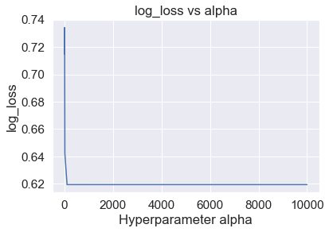

```
best log-loss -  0.7341467234573728
best parameters using l2 is-  0.01
Using L1 regularization:
```

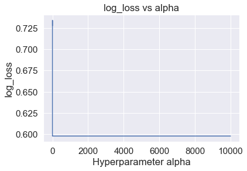

```
best log-loss -  0.7342504035162503
best parameters using l1 is-  0.001
```

```python
LinearSVCsearchCalib(XtrainW2VV,XcvW2VV)
```

```python
sgdW2V= SGDClassifier(loss='hinge', alpha=0.001, penalty='l1')
sgdW2V.fit(XtrainW2VV,Ytrain)
train_pred= sgdW2V.predict(XtrainW2VV)
pred= sgdW2V.predict(XtestW2VV)
```

```
Accuracy on test set: 87.605%
Precision on test set: 87.834
Recall on test set: 99.469
F1-Score on test set: 93.290
```

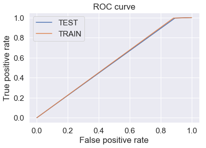

```
Confusion Matrix of test set:
 [ [TN  FP]
 [FN TP] ]
```

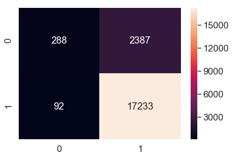

```python
performance(train_pred,pred,sgdW2V)
```

# tfidf-weighted avg w2v vectorization

```python
tfmodel=TfidfVectorizer(max_features=2000)
tf_idf_matrix = tfmodel.fit_transform(Xtrain.values)
tfidf_feat=tfmodel.get_feature_names()
dictionary = {k:v for (k,v) in zip(tfmodel.get_feature_names(), list(tfmodel.idf_))}
```

```python
def tfidfw2vVect(X):
    '''
    This function converts list of sentance into list of list of words and then
    finally applies average-tfidf-w2w to get final sentance vector
    w2v model and w2v words already made during w2v vectorization part
    '''
    lists=[]
    for sent in X.values:
        filtered_sentence=[]
        sent=cleanhtml(sent)
        for w in sent.split():
            for cleaned_words in cleanpunc(w).split():
                if(cleaned_words.isalpha()):
                    filtered_sentence.append(cleaned_words.lower())
                else:
                    continue
        lists.append(filtered_sentence)

    tfidfw2v_sent_vectors = []; # the tfidf-w2v for each sentence/review is stored in this list
    row=0;
    for sent in lists: # for each review/sentence
        sent_vec = np.zeros(50) # as word vectors are of zero length
        weight_sum =0; # num of words with a valid vector in the sentence/review
        for word in sent: # for each word in a review/sentence
            try:
                if word in w2v_words:
                    vec = w2v_model.wv[word]
                    #tf_idf = tf_idf_matrix[row, tfidf_feat.index(word)]
                    #to reduce the computation we are
                    #dictionary[word] = idf value of word in whole courpus
                    #sent.count(word) = tf valeus of word in this review
                    tf_idf = (dictionary[word])*((sent.count(word))/len(sent))
                    sent_vec += (vec * tf_idf)
                    weight_sum += tf_idf
            except:
                pass
        if weight_sum != 0:
            sent_vec /= weight_sum
        tfidfw2v_sent_vectors.append(sent_vec)
        row += 1
    # converting nan and infinte values in vect to digit
    tfidfw2v_sent_vectors= np.nan_to_num(tfidfw2v_sent_vectors)
    return tfidfw2v_sent_vectors
```

```python
# feeding text data and recieving vectorized data
XtrainTFIDFW2VV= tfidfw2vVect(Xtrain)
XcvTFIDFW2VV= tfidfw2vVect(Xcv)
XtestTFIDFW2VV= tfidfw2vVect(Xtest)
```

```python
#Standardizing vectors
std = StandardScaler(with_mean=False).fit(XtrainTFIDFW2VV)
XtrainTFIDFW2VV = std.transform(XtrainTFIDFW2VV)
XcvTFIDFW2VV = std.transform(XcvTFIDFW2VV)
XtestTFIDFW2VV = std.transform(XtestTFIDFW2VV)
```

```
Using L2 regularization:
```

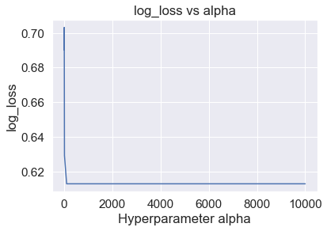

```
best log-loss -  0.7031723155084051
best parameters using l2 is-  0.001
Using L1 regularization:
```

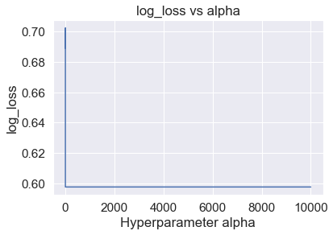

```
best log-loss -  0.7022328300348195
best parameters using l1 is-  0.001
```

```python
#calibratedSVC
LinearSVCsearchCalib(XtrainTFIDFW2VV,XcvTFIDFW2VV)
```

```python
sgdTFIDFW2V= SGDClassifier(loss='hinge', alpha=0.001, penalty='l1')
sgdTFIDFW2V.fit(XtrainTFIDFW2VV,Ytrain)
train_pred= sgdTFIDFW2V.predict(XtrainTFIDFW2VV)
pred= sgdTFIDFW2V.predict(XtestTFIDFW2VV)
```

```
Accuracy on test set: 86.620%
Precision on test set: 86.624
Recall on test set: 99.994
F1-Score on test set: 92.830
```

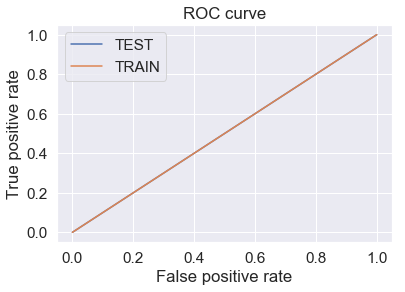

```
Confusion Matrix of test set:
 [ [TN  FP]
 [FN TP] ]
```

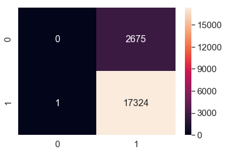

```python
performance(train_pred,pred,sgdTFIDFW2V)
```

# RBF SVM (with 20k datapoints)

```python
#latest 20k points according to time
data= data[:20000]
len(data)
```

```
20000
```

## Splitting data into train60% cv20 test20%

Splitting our data into train and test data.

- train data will train our ML model
- cross validataion data will be for determining our hyperparameter
- test data will tell how Generalized our model is
- dataframes after splitting:- traindata, testdata

```python
traindata, testdata= train_test_split(data, test_size= 0.2, shuffle= False,stratify= None)
traindata, cvdata= train_test_split(traindata, test_size= 0.25, shuffle= False,stratify= None)
```

```python
Xtrain,Xcv,Xtest= traindata['CleanedText'],cvdata['CleanedText'],testdata['CleanedText']
Ytrain,Ycv,Ytest= traindata['Score'],cvdata['Score'],testdata['Score']
```

```python
# converting positive to 1 and negative to -1
Ytrain=Ytrain.map(lambda x:1 if x=='Positive' else -1)
Ycv=Ycv.map(lambda x:1 if x=='Positive' else -1)
Ytest=Ytest.map(lambda x:1 if x=='Positive' else -1)
```

Taking Text and score(class) as sequences

- traindata -> Xtrain, Ytrain
- cvdata -> Xcv, Ycv
- testdata -> Xtest, Ytest

```python
from sklearn.svm import SVC
def SVCsearch(X,Y):
    '''
    We have two hyperparameters in rbf SVC C and gamma
    this function will find best C and gamma using Gridsearch
    '''
    parameters= {'C':[0.0001,0.001,0.01,0.1,1,10,100,1000,10000], 'gamma':[0.0001,0.001,0.01,0.1,1,10,100,1000,10000]}
    svc= SVC(kernel='rbf',max_iter=1000)
    gridcv= GridSearchCV(svc,parameters,scoring='roc_auc',cv=10,n_jobs=-1)
    gridcv.fit(X,Y)
    #plotting
    plt.xlim([0.0001, 0.1])
    scores = [x[1] for x in gridcv.grid_scores_]
    scores= np.array(scores).reshape(9,9)
    for ind,i in enumerate(parameters['C']):
        plt.plot(parameters['gamma'], scores[ind], label='C: ' + str(i))
    plt.legend()
    plt.xlabel('gamma')
    plt.ylabel('roc score')
    plt.show()
    print('best auc- ',gridcv.best_score_)
    print('best parameters- ',gridcv.best_params_)
```

# BOW Vectorization

```python
# vectorizing X and transforming
bowModel=CountVectorizer(min_df = 10, max_features = 500)
XtrainBOWV=bowModel.fit_transform(Xtrain.values)
```

```python
XcvBOWV= bowModel.transform(Xcv)
XtestBOWV= bowModel.transform(Xtest)
XtestBOWV.shape
```

[output not shown]

```python
#Standardizing vectors
std = StandardScaler(with_mean=False).fit(XtrainBOWV)
XtrainBOWV = std.transform(XtrainBOWV)
XcvBOWV = std.transform(XcvBOWV)
XtestBOWV = std.transform(XtestBOWV)
```

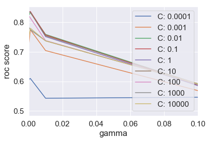

```
best auc-  0.8367880655690559
best parameters-  {'C': 0.1, 'gamma': 0.001}
```

```python
SVCsearch(XcvBOWV,Ycv)
```

```python
#finally training
svcBOW= SVC(kernel='rbf',max_iter=1000,C=0.1,gamma=0.001)
svcBOW.fit(XtrainBOWV,Ytrain)
train_pred= svcBOW.predict(XtrainBOWV)
pred= svcBOW.predict(XcvBOWV)
```

[output not shown]

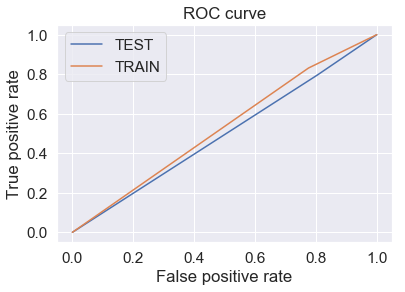

```
Confusion Matrix of test set:
 [ [TN  FP]
 [FN TP] ]
```

[figure not shown]

```python
performance(train_pred,pred,svcBOW)
```

# TFIDF vectorization

```python
# generating vetor out of text using tfidf
tfidfModel=TfidfVectorizer(min_df = 10, max_features = 500)
XtrainTFIDFV= tfidfModel.fit_transform(Xtrain)
XcvTFIDFV= tfidfModel.transform(Xcv)
XtestTFIDFV= tfidfModel.transform(Xtest)
```

```python
std= StandardScaler(with_mean=False)
XtrainTFIDFV = std.fit_transform(XtrainTFIDFV)
XcvTFIDFV = std.transform(XcvTFIDFV)
XtestTFIDFV = std.transform(XtestTFIDFV)
```

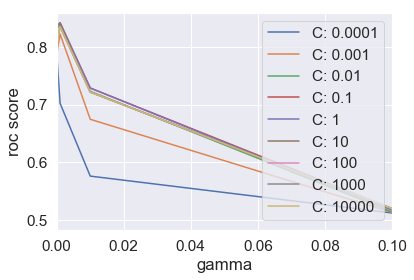

```
best auc-  0.841353375051359
best parameters-  {'C': 1, 'gamma': 0.001}
```

```python
SVCsearch(XcvTFIDFV,Ycv)
```

```python
svcTFIDF= SVC(kernel='rbf',max_iter=1000,C=1,gamma=0.001)
svcTFIDF.fit(XtrainTFIDFV,Ytrain)
train_pred= svcTFIDF.predict(XtrainTFIDFV)
pred= svcTFIDF.predict(XtestTFIDFV)
```

[output not shown]

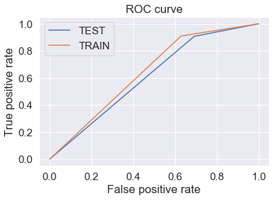

```
Confusion Matrix of test set:
 [ [TN  FP]
 [FN TP] ]
```

[figure not shown]

```python
performance(train_pred,pred,svcTFIDF)
```

# W2V vectorization

```python
# Vectorizing our data
XtrainW2VV= w2vVect(Xtrain)
XcvW2VV= w2vVect(Xcv)
XtestW2VV= w2vVect(Xtest)
```

```python
#Standardizing vectors
std = StandardScaler(with_mean=False).fit(XtrainW2VV)
XtrainW2VV = std.transform(XtrainW2VV)
XcvW2VV = std.transform(XcvW2VV)
XtestW2VV = std.transform(XtestW2VV)
```

```python
XtrainW2VV.shape
```

```
(12000, 50)
```

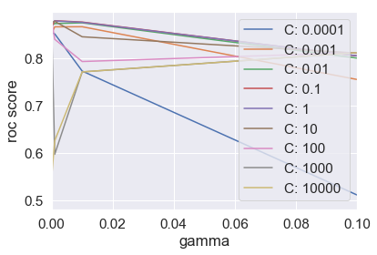

```
best auc-  0.8792813940114392
best parameters-  {'C': 0.1, 'gamma': 0.001}
```

```python
SVCsearch(XcvW2VV,Ycv)
```

```python
svcW2V= SVC(kernel='rbf',max_iter=1000,C=0.1,gamma=0.001)
svcW2V.fit(XtrainW2VV,Ytrain)
train_pred= svcW2V.predict(XtrainW2VV)
pred= svcW2V.predict(XtestW2VV)
```

[output not shown]

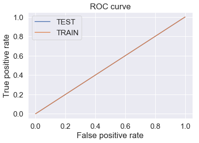

```
Confusion Matrix of test set:
 [ [TN  FP]
 [FN TP] ]
```

[figure not shown]

```python
performance(train_pred,pred,svcW2V)
```

# tfidfw2v vectorization

```python
tfmodel=TfidfVectorizer(max_features=500)
tf_idf_matrix = tfmodel.fit_transform(Xtrain.values)
tfidf_feat=tfmodel.get_feature_names()
dictionary = {k:v for (k,v) in zip(tfmodel.get_feature_names(), list(tfmodel.idf_))}
```

```python
# feeding text data and recieving vectorized data
XtrainTFIDFW2VV= tfidfw2vVect(Xtrain)
XcvTFIDFW2VV= tfidfw2vVect(Xcv)
XtestTFIDFW2VV= tfidfw2vVect(Xtest)
```

```python
#Standardizing vectors
std = StandardScaler(with_mean=False).fit(XtrainTFIDFW2VV)
XtrainTFIDFW2VV = std.transform(XtrainTFIDFW2VV)
XcvTFIDFW2VV = std.transform(XcvTFIDFW2VV)
XtestTFIDFW2VV = std.transform(XtestTFIDFW2VV)
```

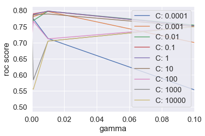

```
best auc-  0.798321800125743
best parameters-  {'C': 1, 'gamma': 0.01}
```

```python
SVCsearch(XcvTFIDFW2VV,Ycv)
```

```python
svcTFIDFW2V= SVC(kernel='rbf',max_iter=1000,C=0.1,gamma=0.001)
svcTFIDFW2V.fit(XtrainTFIDFW2VV,Ytrain)
train_pred= svcTFIDFW2V.predict(XtrainTFIDFW2VV)
pred= svcTFIDFW2V.predict(XtestTFIDFW2VV)
```

[output not shown]

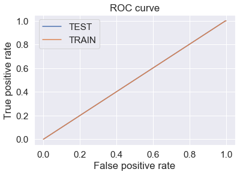

```
Confusion Matrix of test set:
 [ [TN  FP]
 [FN TP] ]
```

[figure not shown]

```python
performance(train_pred,pred,svcTFIDFW2V)
```

# Summary

## LinearSGDClassifier

[output not shown]

## RBF SVM

[output not shown]

## Observations:

```python
print('END\n\n\n')
```

```
END
```